# Stone Data Challenge - Métricas de Performance

Por Max Mitteldorf

## Métricas de Performance

Esta seção tem por objetivo explorar um pouco os resultados da performance do modelo na base de teste. Pretendo explorar como varia a performance do modelo de acordo com o setor ou região do cliente. Também desejo comprovar a superioridade dos resultados de meu modelo em relação à média histórica do TPV.  
Vamos começar importando os pacotes, a fonte de texto que iremos utilizar para os gráficos e os dataframes com as métricsa de performance:

```r
library(tidyverse)
library(showtext)
library(Metrics)
library(grid)
library(ggcharts)
library(mdthemes)

## Importing font
font_add(family = "Sharon", regular = "visualization/fonts/Sharon.ttf")
showtext_auto()

### Reading dataframes
df_perf = read_csv("data/model/performance/df_performance.csv") %>%
  select(-1)
df_tpvs = read_csv("data/clean/stone_data_cleaned.csv")
```

Primeiramente vou juntar a base de dados de dados cadastrais e de TPVs com a base de dados de performance. TIve que realizar algumas pivotagens e manipulações para isso, como pode ser observado no código abaixo:

```r
### Getting last five rows for each id
df_tpvs = df_tpvs %>%
  arrange(id, mes_referencia) %>%
  group_by(id) %>%
  slice_tail(n=5) %>%
  select(-mes_referencia, -TPV_mensal) %>%
  unique()

### Pivoting dataframes for merge
df_tpv_real = df_perf %>%
  pivot_longer(starts_with("TPV_t"), values_to="TPV_mensal", names_to="lag") %>%
  select(id, TPV_mensal, lag)

df_tpv_pred = df_perf %>%
  pivot_longer(starts_with("TPV_pred_t"), values_to="TPV_pred", names_to="lag") %>%
  select(TPV_pred, TPV_historic_mean)

### Merging dataframes
df_comp = bind_cols(df_tpv_pred, df_tpv_real) %>%
  select(id, everything()) %>%
  mutate(lag=as.numeric(str_remove(lag, "TPV_t")))
rm(df_tpv_real)
rm(df_tpv_pred)

### Transforming df_comp to long format to plot graphs
df_comp_long = df_comp %>%
  pivot_longer(-c(id, lag), values_to="valor", names_to="tipo")
```

Antes de continuar gostaria de mostrar as primeiras linhas da base que utilizarei para os gráficos. Quero ressaltar que não há entradas para alguns clientes pois tive que selecionar apenas clientes com no mínimo 6 meses de histórico para treinar o modelo

```r
head(df_comp, n=15)
```

```
## # A tibble: 15 x 5
##       id TPV_pred TPV_historic_mean TPV_mensal   lag
##    <dbl>    <dbl>             <dbl>      <dbl> <dbl>
##  1     1   11408.            11570.     12207.     1
##  2     1   19065.            11570.     10459.     2
##  3     1   27956.            11570.     17708.     3
##  4     1   19995.            11570.     12749.     4
##  5     1   20597.            11570.     17156.     5
##  6     3    2726.             2267.      2643.     1
##  7     3    2531.             2267.      4430.     2
##  8     3    2830.             2267.      4552.     3
##  9     3    2680.             2267.      4005.     4
## 10     3    2822.             2267.      3444.     5
## 11     4   38850.            52883.     38428.     1
## 12     4   41464.            52883.     21209.     2
## 13     4   49477.            52883.     26268.     3
## 14     4   65904.            52883.     28057.     4
## 15     4   45860.            52883.     31950.     5
```

Para começar, algo muito interessante que podemos visualizar é a performance do modelo e da média histórica do TPV para cada cliente. Vou mostrar esses resultados para os primeiros clientes:

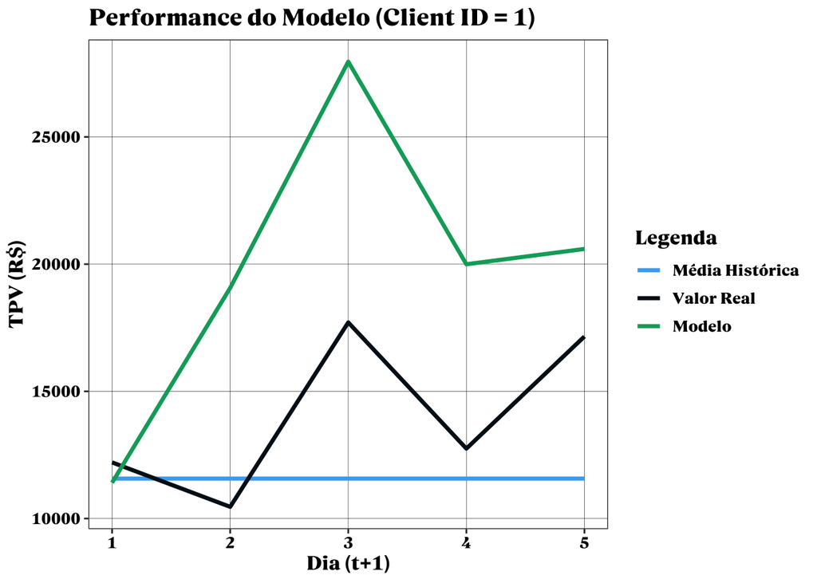

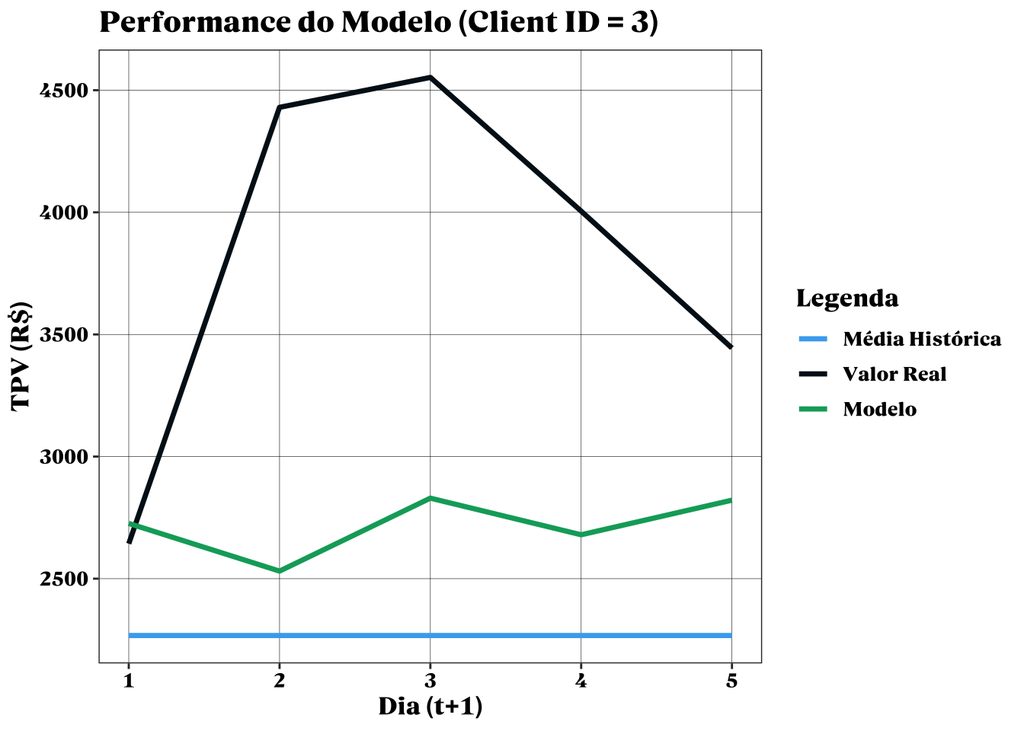

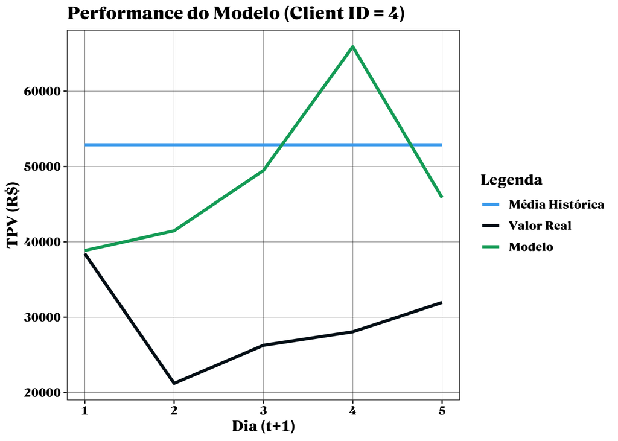

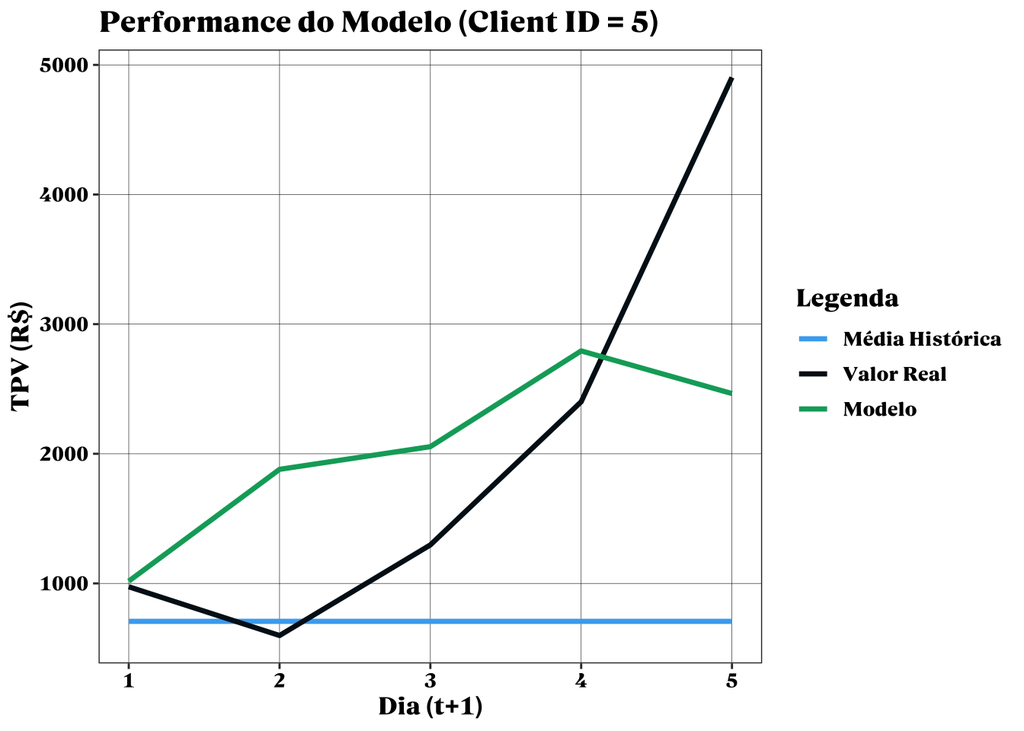

Podemos ver que na maior parte dos casos a reta de previsões de nosso modelo está mais próxima do valor real do que a média móvel, o que é um sinal muito promissor.  
Agora vamos juntar à nossa base os dados cadastrais dos clientes para investigarmos a performance do modelo em diferentes setores econômicos:

```r
### Merging performance dataframe with df_comp
df_complete = inner_join(df_comp, df_tpvs, by="id") %>%
  select(-lag)

### Grouping by id and getting the mean MAE for each client
df_complete = df_complete %>%
  group_by(id) %>%
  summarise(id, MAE_model = mae(TPV_mensal, TPV_pred), MAE_mean=mae(TPV_historic_mean, TPV_mensal),
    MacroClassificacao, Estado, segmento) %>% unique()
```

Agora que temos todos os dados juntos vamos investigar a performance de nosso modelo de acordo com a Macro Classificação:

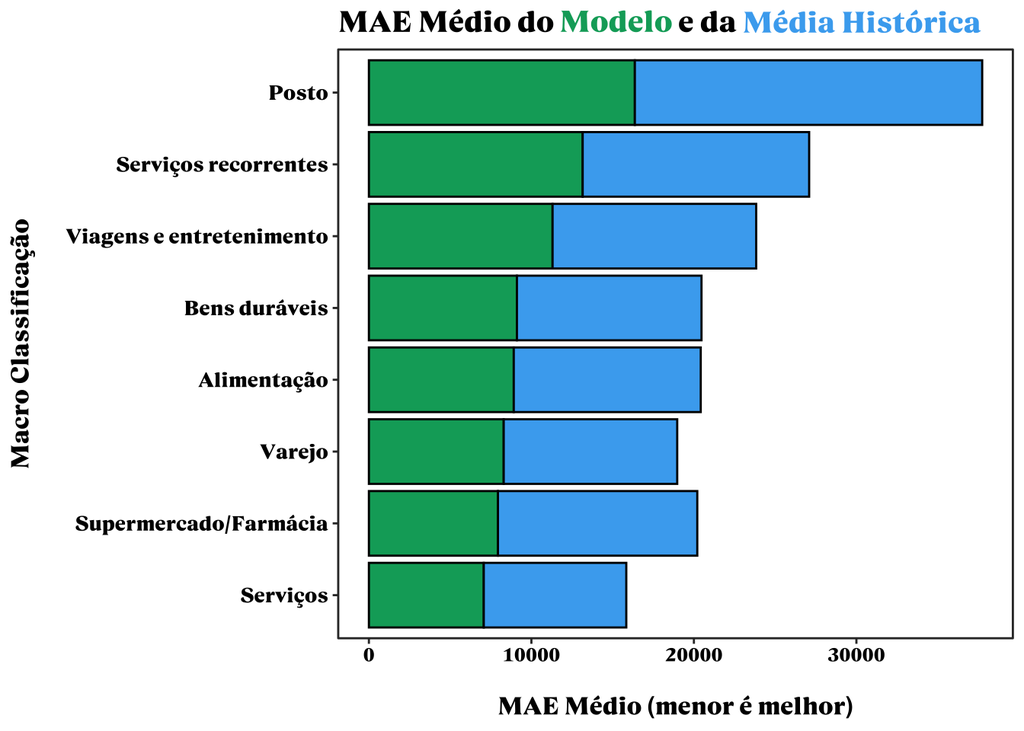

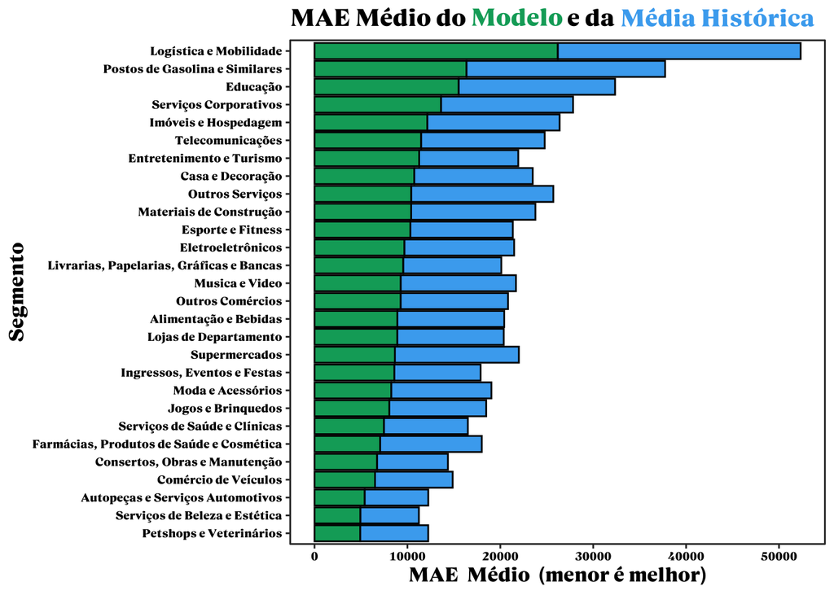

Nessa visão menos agrupada podemos ver que a performance do modelo é bem elevada no setor de Petshops e Veterinários, Serviços de Beleza e Estética, e Autopeças e Serviços Autimotivos. Mais uma vez o setor de Postos de Gasolina demonstra ser difícil de prever para o modelo, sendo superado pelo de Logística e Mobilidade. Muito provavelmente a baixa performance em relação a esses setores tem relação com o preço dos combustíveis, uma variável que pretendo incluir no modelo caso eu prossiga no desafio.  
Agora que já vimos a performance do modelo de acordo com o segmento econômico vamos observar a performance de acordo com o estado da federação, para ver se o modelo tem dificuldades particulares em algum estado:

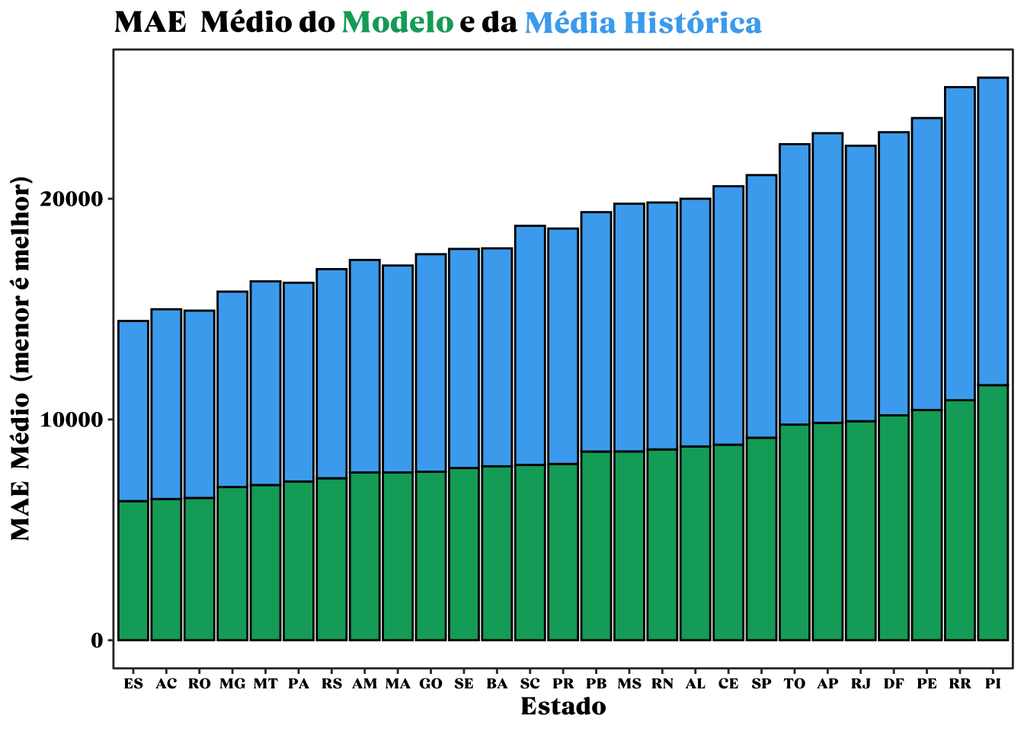

É possível observar que nosso modelo apresenta uma variabilidade muito meor em relação ao erro absoluto médio quando comparamos com a performance da média histórica, um sinal muito promissor. Mesmo assim vemos que o modelo possui uma considerável diferença de performance quando comparamos estados como o Espirito Santo e Piauí. Uma variável que poderíamos adicionar ao modelo para tentar captar essas diferenças é o número de casos de covid no último mês, porque sabemos que a pandemia não ocorre de forma homogênea no território nacional e certamente tem um impacto nas atividades econômicas.  
Para finalizar vamos comparar os gráficos de dispersão entre as previsões de nosso modelo com os valores reais do TPV, e entre a média histórica do TPV e os valores reais:

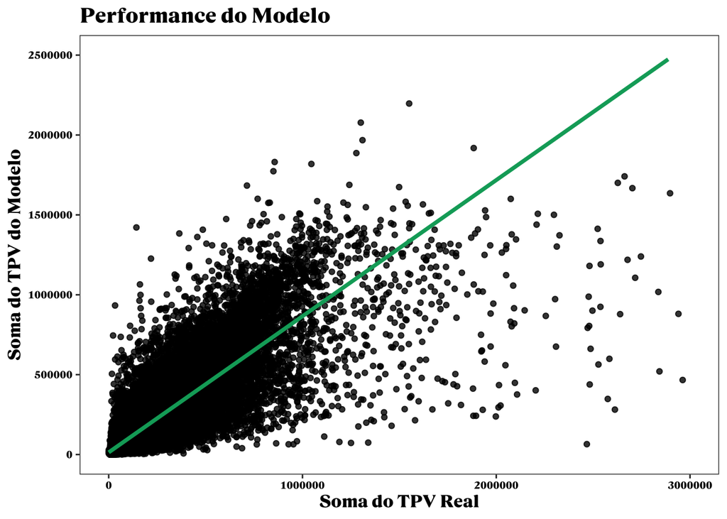

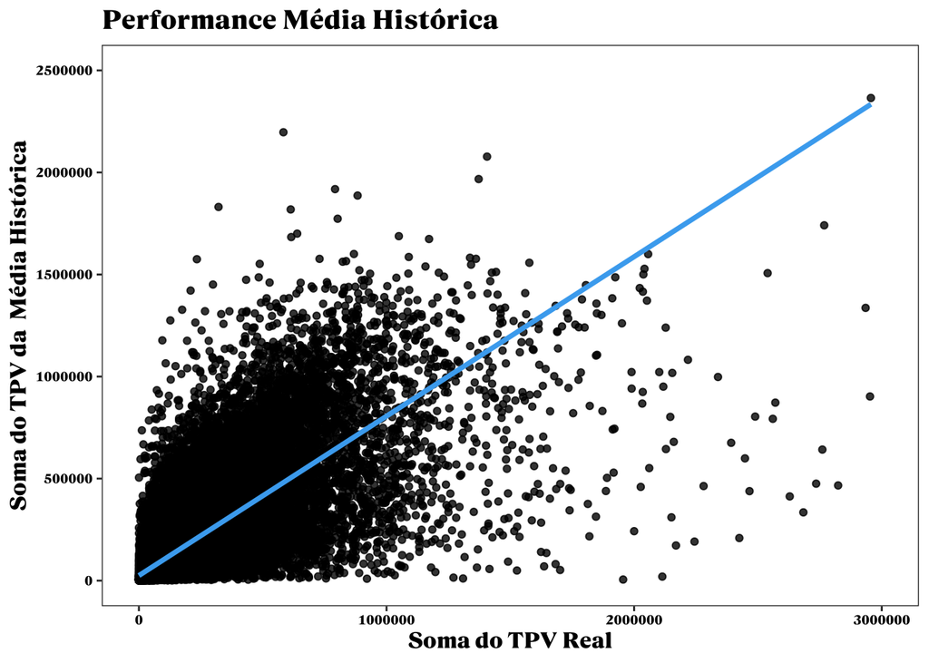

Agora vamos juntar as duas linhas de regressão em um só gráfico para ver qual possui a maior inclinação:

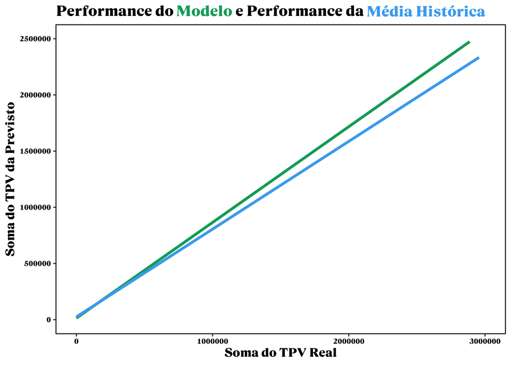

Podemos ver que a inclinação da reta do modelo (verde) é claramente superior, demonstrando que pelo menos para a base de teste nosso modelo claramentesupera a performance da média histórica do TPV.

## Conclusão

Gostaria de dizer que foi um grande prazer participar deste desafio. Independentemente de qualquer resultado ou métrica de performance aprendi bastante sobre problemas de séries temporais e alguns métodos específicos a esses problemas. Espero que o conteúdo tenha sido interessante e prazerosa para vocês, assim como foi escrevê-lo.